# Exploring the Factors that Influence Sleep Health: A Data Driven Approach

Collaboration by Mohan Dasari, Meehan Imam, Aishani Mukherjee, Roha Tabbasam

## Introduction

### Importance of Sleep and Occupational Stress

In today's fast-paced world, sleep often becomes a neglected aspect of our daily routines, yet its importance is profound in maintaining overall well-being and health. Sleep is not merely a time to rest but a critical biological function that restores and rejuvenates the mind and body. Deprivation of sleep can lead to a multitude of health problems such as, reducing mental clarity, undermining emotional stability, and even increasing the risk of chronic conditions (Worley, "The Extraordinary Importance of Sleep: The Detrimental Effects of Inadequate Sleep on Health and Public Safety Drive an Explosion of Sleep Research").

Occupational stress often arises from the unique challenges of different job roles and the demanding nature of certain professions may affect sleep patterns. Therefore, understanding how various lifestyle factors contribute to stress within specific occupations becomes imperative. Studies have linked adequate sleep to improved memory, mood stability, and physical health, including the regulation of metabolism and reduction of chronic diseases such as diabetes and heart disease (Worley, "The Extraordinary Importance of Sleep: The Detrimental Effects of Inadequate Sleep on Health and Public Safety Drive an Explosion of Sleep Research").

### Exploring Occupational Sleep Dynamics

The question of why we sleep gains added significance when considering the diverse demands of different occupations. Sleep is a complex biological process that significantly impacts cognitive functions, hormone balance, and even the healing of the heart and blood vessels. The amount of sleep needed varies widely depending on factors like age, lifestyle, and health conditions. Recognizing these variations within the context of specific professions can illuminate the unique challenges each occupation faces in maintaining quality sleep.

This project aims to delve into the multifaceted factors contributing to sleep patterns among various occupations, with a particular focus on understanding the relationship between lifestyle choices and occupational stress. By harnessing the power of data science, this study seeks to unravel the intricate connections between stress and different aspects such as age, gender, sleep duration, and physical activity levels that impact specific job roles.

### Importance of Data Science

How can we figure out what affects our sleep quality and how to improve it? That is where data science comes in. Data science is like a detective that can find clues and solve mysteries from huge amounts of data. It can help us discover how different factors, such as age, lifestyle, medical history, and work environment, influence our sleep patterns and stress levels in different professions.

Data science can do more than just reveal the past, it can also help us shape the future. By using the data provided from these two datasets, we can create models that can predict how our sleep and stress are intertwined with each other. Furthermore, these predictive models can empower individuals to make informed decisions about their habits and routines, allowing them to proactively address sleep-related issues and manage stress for a healthier and more balanced lifestyle.

### Purpose

The intention of this project is to explore the factors that affect occupational stress, with an emphasis on sleep-related factors and uncover insights that can guide interventions, policies, and personal strategies to mitigate sleep-related occupational stress. By comprehending the specific factors that affect sleep within each profession, we can tailor recommendations that foster healthier sleep practices for individuals and entire occupational communities.

Various aspects such as lifestyle choices, environmental factors, medical conditions, and psychological stressors will be examined to unravel their impact on stress for various job roles. Data science, with its ability to process complex data and highlight underlying trends, becomes an indispensable tool in this exploration. Moreover, recognizing that sleep's influence extends to every facet of health, this project embarks on a vital journey to dissect the dynamics of sleep and its impact on various professions. The knowledge gained from this exploration will not only enrich our understanding but will pave the way for targeted interventions and policies aimed at enhancing the quality of life through improved sleep practices, thereby bolstering the well-being of individuals across different job roles.

## Data Collection

In the first step of the Data Science life cycle, our primary focus is sourcing a dataset that aligns with the subject under investigation. In the context of our research on stress, sleep, and health in the U.S., we initiated a search for a relevant dataset. The dataset are utilizing is the "Sleep Health and Lifestyle Dataset," which has been curated by a health professional, Laksika Tharmalingam, and is accessible on [Kaggle](https://www.kaggle.com/datasets/uom190346a/sleep-health-and-lifestyle-dataset).

Yet, acquiring this dataset alone doesn't suffice, as our objective encompasses understanding the influence of stress-inducing factors on sleep patterns. We investigated an additional dataset available on [Kaggle](https://www.kaggle.com/datasets/laavanya/human-stress-detection-in-and-through-sleep) titled "Human Stress Detection in and through Sleep," curated by another healthcare expert, Laavanya Rachakonda.

In the course of this project, we will leverage the Python programming language and employ tools in its libraries for the project's development.

```python
# Import the following libraries to aid in the analysis of the datasets
import numpy as np
import pandas as pd

import matplotlib.pyplot as plt
import seaborn as sns

import statsmodels.formula.api as stm
from sklearn.preprocessing import StandardScaler
from sklearn import linear_model
from sklearn.model_selection import train_test_split
from sklearn.metrics import mean_squared_error

pd.set_option('display.max_columns', None)
```

The "Sleep Health and Lifestyle Dataset" dataset records 374 individuals and 13 feature categories, encompassing an extensive array of factors linked to sleep patterns and everyday routines. The dataset contains information including gender, age, occupation, sleep duration, sleep quality, physical activity level, stress levels, BMI category, blood pressure, heart rate, daily step count, and the presence or absence of sleep disorders. Through our analysis, we aim to gain valuable insights into the intricate interplay between these variables and their impact on occupations.

```python
# Read in the CSV file for the "Sleep Health and Lifestyle" dataset into a dataframe
sleep_health_and_lifestyle_df = pd.read_csv('Sleep_health_and_lifestyle_dataset.csv')

sleep_health_and_lifestyle_df.head(10)
```

|  | Person ID | Gender | Age | Occupation | Sleep Duration | Quality of Sleep | Physical Activity Level | Stress Level | BMI Category | Blood Pressure | Heart Rate | Daily Steps | Sleep Disorder |
| --- | --- | --- | --- | --- | --- | --- | --- | --- | --- | --- | --- | --- | --- |
| 0 | 1 | Male | 27 | Software Engineer | 6.1 | 6 | 42 | 6 | Overweight | 126/83 | 77 | 4200 | None |
| 1 | 2 | Male | 28 | Doctor | 6.2 | 6 | 60 | 8 | Normal | 125/80 | 75 | 10000 | None |
| 2 | 3 | Male | 28 | Doctor | 6.2 | 6 | 60 | 8 | Normal | 125/80 | 75 | 10000 | None |
| 3 | 4 | Male | 28 | Sales Representative | 5.9 | 4 | 30 | 8 | Obese | 140/90 | 85 | 3000 | Sleep Apnea |
| 4 | 5 | Male | 28 | Sales Representative | 5.9 | 4 | 30 | 8 | Obese | 140/90 | 85 | 3000 | Sleep Apnea |
| 5 | 6 | Male | 28 | Software Engineer | 5.9 | 4 | 30 | 8 | Obese | 140/90 | 85 | 3000 | Insomnia |
| 6 | 7 | Male | 29 | Teacher | 6.3 | 6 | 40 | 7 | Obese | 140/90 | 82 | 3500 | Insomnia |
| 7 | 8 | Male | 29 | Doctor | 7.8 | 7 | 75 | 6 | Normal | 120/80 | 70 | 8000 | None |
| 8 | 9 | Male | 29 | Doctor | 7.8 | 7 | 75 | 6 | Normal | 120/80 | 70 | 8000 | None |
| 9 | 10 | Male | 29 | Doctor | 7.8 | 7 | 75 | 6 | Normal | 120/80 | 70 | 8000 | None |

The "Human Stress Detection in and through Sleep" dataset records 630 individuals and 8 feature categories. The dataset stems from a special pillow (Smart-Yoga Pillow) that has a clever processor. This processor looks at how our body changes while we sleep and how we sleep. The dataset tracks information including tracks snoring rate, breathing rate, body temperature, movement, oxygen levels, eye movement, hours of sleep, heartbeats, and stress levels. Through this dataset, we gain a comprehensive understanding of sleep-related physiological dynamics, contributing to the broader field of sleep research and technology.

```python
# Read in the CSV file for the "Human Stress Detection in and through Sleep" dataset into a dataframe
stress_detection_and_sleep_df = pd.read_csv('SayoPillow.csv')

stress_detection_and_sleep_df.head(10)
```

|  | sr | rr | t | lm | bo | rem | sr.1 | hr | sl |
| --- | --- | --- | --- | --- | --- | --- | --- | --- | --- |
| 0 | 93.80 | 25.680 | 91.840 | 16.600 | 89.840 | 99.60 | 1.840 | 74.20 | 3 |
| 1 | 91.64 | 25.104 | 91.552 | 15.880 | 89.552 | 98.88 | 1.552 | 72.76 | 3 |
| 2 | 60.00 | 20.000 | 96.000 | 10.000 | 95.000 | 85.00 | 7.000 | 60.00 | 1 |
| 3 | 85.76 | 23.536 | 90.768 | 13.920 | 88.768 | 96.92 | 0.768 | 68.84 | 3 |
| 4 | 48.12 | 17.248 | 97.872 | 6.496 | 96.248 | 72.48 | 8.248 | 53.12 | 0 |
| 5 | 56.88 | 19.376 | 95.376 | 9.376 | 94.064 | 83.44 | 6.376 | 58.44 | 1 |
| 6 | 47.00 | 16.800 | 97.200 | 5.600 | 95.800 | 68.00 | 7.800 | 52.00 | 0 |
| 7 | 50.00 | 18.000 | 99.000 | 8.000 | 97.000 | 80.00 | 9.000 | 55.00 | 0 |
| 8 | 45.28 | 16.112 | 96.168 | 4.224 | 95.112 | 61.12 | 7.112 | 50.28 | 0 |
| 9 | 55.52 | 19.104 | 95.104 | 9.104 | 93.656 | 82.76 | 6.104 | 57.76 | 1 |

## Data Processing

Before examining the data presented, we need to process and tidy the data to make it more suitable for exploratory analysis within the Data Science lifecycle. The tabular dataset for "Sleep Health and Lifestyle" has a few organization issues that may make it difficult for readability and analysis.

By processing and tidying up the data, we can get better insight into the arrangement of the records within each dataset.

### Tidying "Sleep Health and Lifestyle Dataset" Dataset

We will clean up the dataset by ridding it of any unnecessary columns, renaming and rearranging columns, and converting specific value types as one-hot encodings for improved analysis on the data.

Fortunately, no missing data was detected from the dataset, therefore we will not have to impute missing values into the data.

```python
# Make one-hot encoding for the different occupations in the dataset
sleep_health_and_lifestyle_df_tidy = pd.get_dummies(sleep_health_and_lifestyle_df, columns=['Occupation'], drop_first=True)

# Encode Gender columns
sleep_health_and_lifestyle_df_tidy['Gender'] = sleep_health_and_lifestyle_df['Gender'].map({'Male': 1, 'Female': 0})

# Convert numerical data types into floats for easier use later on
features_to_convert = ['Age', 'Physical Activity Level', 'Stress Level', 'Daily Steps', 'Sleep Duration']
sleep_health_and_lifestyle_df_tidy[features_to_convert] = sleep_health_and_lifestyle_df_tidy[features_to_convert].astype(float)

# Drop unnecessary columns from the dataset and add original 'Occupation' column from original dataset
features_to_drop = ['Quality of Sleep', 'BMI Category', 'Blood Pressure', 'Heart Rate', 'Sleep Disorder', 'Daily Steps']
sleep_health_and_lifestyle_df_tidy.drop(columns=features_to_drop, inplace=True)
sleep_health_and_lifestyle_df_tidy['Occupation'] = sleep_health_and_lifestyle_df['Occupation']

# Rename appropriate columns for clarity
feature_renaming = {
    'Person ID': 'Person_ID',
    'Sleep Duration': 'Sleep_Duration',
    'Physical Activity Level': 'Physical_Activity_Level',
    'Stress Level': 'Stress_Level',
    'Occupation_Software Engineer': 'Occupation_Software_Engineer',
    'Occupation_Sales Representative': 'Occupation_Sales_Representative'
}
sleep_health_and_lifestyle_df_tidy.rename(columns=feature_renaming, inplace=True)

# Rearrange columns for clarity
sleep_health_and_lifestyle_df_tidy = sleep_health_and_lifestyle_df_tidy[['Person_ID', 'Gender', 'Age', 'Sleep_Duration', 'Physical_Activity_Level', 'Occupation', 'Occupation_Doctor', 'Occupation_Engineer', 'Occupation_Lawyer', 'Occupation_Manager', 'Occupation_Nurse', 'Occupation_Sales_Representative', 'Occupation_Salesperson', 'Occupation_Scientist', 'Occupation_Software_Engineer', 'Occupation_Teacher', 'Stress_Level']]

sleep_health_and_lifestyle_df_tidy.head(10)
```

|  | Person_ID | Gender | Age | Sleep_Duration | Physical_Activity_Level | Occupation | Occupation_Doctor | Occupation_Engineer | Occupation_Lawyer | Occupation_Manager | Occupation_Nurse | Occupation_Sales_Representative | Occupation_Salesperson | Occupation_Scientist | Occupation_Software_Engineer | Occupation_Teacher | Stress_Level |
| --- | --- | --- | --- | --- | --- | --- | --- | --- | --- | --- | --- | --- | --- | --- | --- | --- | --- |
| 0 | 1 | 1 | 27.0 | 6.1 | 42.0 | Software Engineer | 0 | 0 | 0 | 0 | 0 | 0 | 0 | 0 | 1 | 0 | 6.0 |
| 1 | 2 | 1 | 28.0 | 6.2 | 60.0 | Doctor | 1 | 0 | 0 | 0 | 0 | 0 | 0 | 0 | 0 | 0 | 8.0 |
| 2 | 3 | 1 | 28.0 | 6.2 | 60.0 | Doctor | 1 | 0 | 0 | 0 | 0 | 0 | 0 | 0 | 0 | 0 | 8.0 |
| 3 | 4 | 1 | 28.0 | 5.9 | 30.0 | Sales Representative | 0 | 0 | 0 | 0 | 0 | 1 | 0 | 0 | 0 | 0 | 8.0 |
| 4 | 5 | 1 | 28.0 | 5.9 | 30.0 | Sales Representative | 0 | 0 | 0 | 0 | 0 | 1 | 0 | 0 | 0 | 0 | 8.0 |
| 5 | 6 | 1 | 28.0 | 5.9 | 30.0 | Software Engineer | 0 | 0 | 0 | 0 | 0 | 0 | 0 | 0 | 1 | 0 | 8.0 |
| 6 | 7 | 1 | 29.0 | 6.3 | 40.0 | Teacher | 0 | 0 | 0 | 0 | 0 | 0 | 0 | 0 | 0 | 1 | 7.0 |
| 7 | 8 | 1 | 29.0 | 7.8 | 75.0 | Doctor | 1 | 0 | 0 | 0 | 0 | 0 | 0 | 0 | 0 | 0 | 6.0 |
| 8 | 9 | 1 | 29.0 | 7.8 | 75.0 | Doctor | 1 | 0 | 0 | 0 | 0 | 0 | 0 | 0 | 0 | 0 | 6.0 |
| 9 | 10 | 1 | 29.0 | 7.8 | 75.0 | Doctor | 1 | 0 | 0 | 0 | 0 | 0 | 0 | 0 | 0 | 0 | 6.0 |

#### Participant Demographics and Understanding Different Groupings of Features for this Dataset

We see different features such as gender, age, occupation, and so on. These features can be isolated and split into different groupings:

1. Participant identity
2. Sleep statistics
3. Physical activity
4. Health conditions

To begin, we'll gather and analyze the participants' information to gain a deeper understanding of their backgrounds.

```python
# List out the total number of Participants, the age range, and occupations to get an idea of the participant demographic
num_people = len(sleep_health_and_lifestyle_df_tidy)

min_age = sleep_health_and_lifestyle_df_tidy['Age'].min()
max_age = sleep_health_and_lifestyle_df_tidy['Age'].max()

occupations = sleep_health_and_lifestyle_df_tidy['Occupation'].unique()

print(f"Number of participants: {num_people}")
print(f"Range of ages: {min_age} - {max_age}")
print("Different occupations:", ', '.join(occupations))
```

```
Number of participants: 374
Range of ages: 27.0 - 59.0
Different occupations: Software Engineer, Doctor, Sales Representative, Teacher, Nurse, Engineer, Accountant, Scientist, Lawyer, Salesperson, Manager
```

With this information there are a couple of generalizations we can make. We know that, for the most part, all of these participants work white-collared jobs. The age range of participants are people who are in or near to the 'middle' of their life. There are only 374 participants, so the sample size in comparison to rest of the world is quite small. There is also a lack of information in where these participants hail from other than being American citizens.

### Tidying "Human Stress Detection in and through Sleep" Dataset

```python
# Create a new dataframe for tidy data
stress_detection_and_sleep_df_tidy = pd.DataFrame(stress_detection_and_sleep_df)

# Drop columns that are unnecessary
stress_detection_and_sleep_df_tidy.drop(['sr', 'rr','lm', 'bo'], axis=1, inplace=True)

# Rename the column names for readability
stress_detection_and_sleep_df_tidy.columns = ['body_temp', 'rem_sleep', 'sleep_duration', 'heart_rate', 'stress_level']

# Convert numerical data types into floats for easier use later on
stress_detection_and_sleep_df_tidy['stress_level'] = stress_detection_and_sleep_df_tidy['stress_level'].astype(float)

stress_detection_and_sleep_df_tidy.head()
```

|  | body_temp | rem_sleep | sleep_duration | heart_rate | stress_level |
| --- | --- | --- | --- | --- | --- |
| 0 | 91.840 | 99.60 | 1.840 | 74.20 | 3.0 |
| 1 | 91.552 | 98.88 | 1.552 | 72.76 | 3.0 |
| 2 | 96.000 | 85.00 | 7.000 | 60.00 | 1.0 |
| 3 | 90.768 | 96.92 | 0.768 | 68.84 | 3.0 |
| 4 | 97.872 | 72.48 | 8.248 | 53.12 | 0.0 |

#### Participant Demographics and Understanding Different Groupings of Features for this Dataset

In the following dataset, we do not see the demographics of a participant other than specific health data. These records of sleep health data is essential for determining a correlation between sleep duration and stress level.

However to begin, we'll gather a general overview on the participants' information to gain a deeper understanding of their health status as a whole.

```python
# List out the total number of Participants, the age range, and occupations to get an idea of the participant demographic
num_people = len(stress_detection_and_sleep_df_tidy)

min_stress_level = stress_detection_and_sleep_df_tidy['stress_level'].min()
max_stress_level = stress_detection_and_sleep_df_tidy['stress_level'].max()

min_body_temp = stress_detection_and_sleep_df_tidy['body_temp'].min()
max_body_temp = stress_detection_and_sleep_df_tidy['body_temp'].max()

min_rem_sleep = stress_detection_and_sleep_df_tidy['rem_sleep'].min()
max_rem_sleep = stress_detection_and_sleep_df_tidy['rem_sleep'].max()

min_sleep_duration = stress_detection_and_sleep_df_tidy['sleep_duration'].min()
max_sleep_duration = stress_detection_and_sleep_df_tidy['sleep_duration'].max()

min_heart_rate = stress_detection_and_sleep_df_tidy['heart_rate'].min()
max_heart_rate = stress_detection_and_sleep_df_tidy['heart_rate'].max()

print(f"Number of participants: {num_people}")
print(f"Range of Stress Levels: {min_stress_level} - {max_stress_level}")
print(f"Range of Body Temperature: {min_body_temp} - {max_body_temp}")
print(f"Range of REM sleep factor: {min_rem_sleep} - {max_rem_sleep}")
print(f"Range of Sleep Durations: {min_sleep_duration} - {max_sleep_duration}")
print(f"Range of Heart Rates: {min_heart_rate} - {max_heart_rate}")
```

```
Number of participants: 630
Range of Stress Levels: 0.0 - 4.0
Range of Body Temperature: 85.0 - 99.0
Range of REM sleep factor: 60.0 - 105.0
Range of Sleep Durations: 0.0 - 9.0
Range of Heart Rates: 50.0 - 85.0
```

Viewing this information, we can see that there are a total of 630 participants. Out of these participants, they also have a range of sleeping records for a sitting. The stress levels vary in range with 0 being the lowest and 4 being the highest stress level, as indicated by the participants. The body temperature, REM sleep factor, and heart rates have various ranges that fall within normal levels. One can see that the range of sleeping durations can start from no sleep (0 hours) to a whole 9 hours of sleep, which may entail to different conclusions as we continue analyzing the data.

The significance within each of these datasets can be further explored in the next phase of the Data Science Lifecycle.

## Exploratory Analysis and Data Visualization for "Sleep Health and Lifestyle Dataset"

For clarity, we will analyze each dataset separately before determining factors that are significant through data modeling.

In this phase of the Data Science Lifecycle, visualizing the data through graphs helps us grasp its nuances more effectively. Alongside this, employing statistical analyses enables us to quantitatively validate and explore the potential trends we identify. Ultimately, this combination of visualization and analysis enhances our understanding of the data's underlying insights.

```python
# Present statistics from the "Sleep Health and Lifestyle Dataset"
descriptive_statistics = sleep_health_and_lifestyle_df_tidy.describe()
descriptive_statistics
```

|  | Person_ID | Gender | Age | Sleep_Duration | Physical_Activity_Level | Occupation_Doctor | Occupation_Engineer | Occupation_Lawyer | Occupation_Manager | Occupation_Nurse | Occupation_Sales_Representative | Occupation_Salesperson | Occupation_Scientist | Occupation_Software_Engineer | Occupation_Teacher | Stress_Level |
| --- | --- | --- | --- | --- | --- | --- | --- | --- | --- | --- | --- | --- | --- | --- | --- | --- |
| count | 374.000000 | 374.000000 | 374.000000 | 374.000000 | 374.000000 | 374.000000 | 374.000000 | 374.000000 | 374.000000 | 374.000000 | 374.000000 | 374.000000 | 374.000000 | 374.000000 | 374.000000 | 374.000000 |
| mean | 187.500000 | 0.505348 | 42.184492 | 7.132086 | 59.171123 | 0.189840 | 0.168449 | 0.125668 | 0.002674 | 0.195187 | 0.005348 | 0.085561 | 0.010695 | 0.010695 | 0.106952 | 5.385027 |
| std | 108.108742 | 0.500641 | 8.673133 | 0.795657 | 20.830804 | 0.392699 | 0.374766 | 0.331919 | 0.051709 | 0.396876 | 0.073029 | 0.280090 | 0.103001 | 0.103001 | 0.309466 | 1.774526 |
| min | 1.000000 | 0.000000 | 27.000000 | 5.800000 | 30.000000 | 0.000000 | 0.000000 | 0.000000 | 0.000000 | 0.000000 | 0.000000 | 0.000000 | 0.000000 | 0.000000 | 0.000000 | 3.000000 |
| 25% | 94.250000 | 0.000000 | 35.250000 | 6.400000 | 45.000000 | 0.000000 | 0.000000 | 0.000000 | 0.000000 | 0.000000 | 0.000000 | 0.000000 | 0.000000 | 0.000000 | 0.000000 | 4.000000 |
| 50% | 187.500000 | 1.000000 | 43.000000 | 7.200000 | 60.000000 | 0.000000 | 0.000000 | 0.000000 | 0.000000 | 0.000000 | 0.000000 | 0.000000 | 0.000000 | 0.000000 | 0.000000 | 5.000000 |
| 75% | 280.750000 | 1.000000 | 50.000000 | 7.800000 | 75.000000 | 0.000000 | 0.000000 | 0.000000 | 0.000000 | 0.000000 | 0.000000 | 0.000000 | 0.000000 | 0.000000 | 0.000000 | 7.000000 |
| max | 374.000000 | 1.000000 | 59.000000 | 8.500000 | 90.000000 | 1.000000 | 1.000000 | 1.000000 | 1.000000 | 1.000000 | 1.000000 | 1.000000 | 1.000000 | 1.000000 | 1.000000 | 8.000000 |

We will ignore the first column with Person_ID as it is only used as a means of identification. Looking at the rest of these statistics, here are some observations we notice for different features:

- Age: The age of individuals ranges from 27 to 59, with a mean of 42.
- Sleep Duration: Sleep duration varies from 5.8 to 8.5 hours, with a mean of 7.13 hours.
- Physical Activity Level: This feature has a mean value of 59.17, with a minimum of 30 and a maximum of 90.
- Stress Level: Stress level ranges from 3 to 8, with a mean value of 5.39.

#### Participant Distribution Based on Features Disregarding Sleep

We will examine the participant distribution of the dataset for various features in order to get an idea of our dataset.

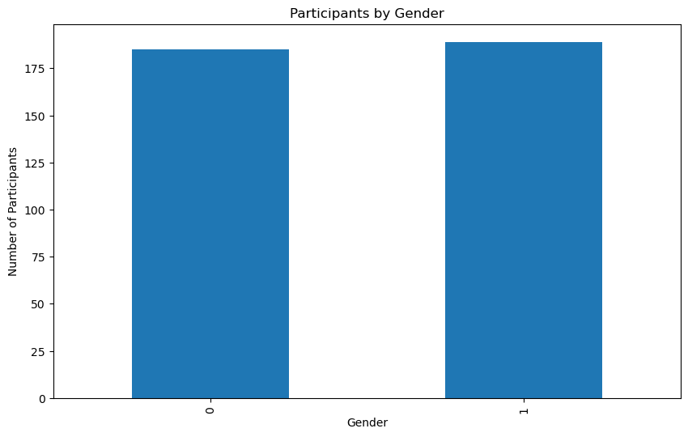

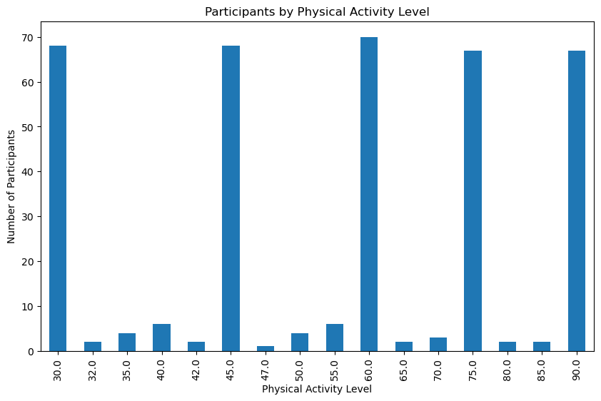

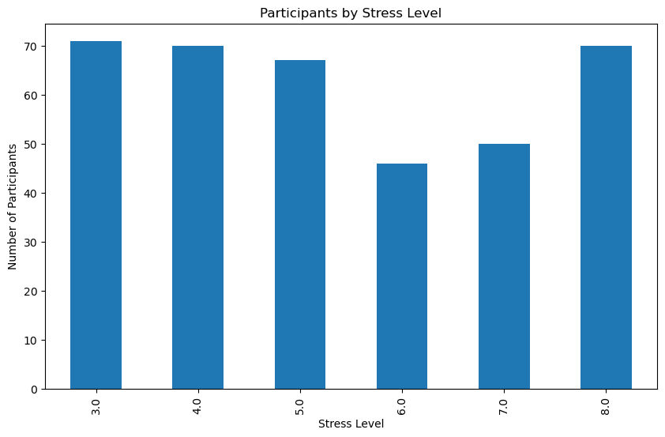

```python
# Plot the different columns of Gender, Physical Activity Level, and Stress Level
feature_columns = ['Gender', 'Physical_Activity_Level', 'Stress_Level']

for feature in feature_columns:
    count = sleep_health_and_lifestyle_df_tidy[feature].value_counts()
    count.sort_index(inplace=True)

    plt.figure(figsize=(10, 6))
    count.plot(kind='bar')
    plt.title(f'Participants by {feature.replace("_", " ").title()}')
    plt.xlabel(feature.replace("_", " ").title())
    plt.ylabel('Number of Participants')
    plt.show()
```

From the distributions above we can see a few generalizations of the dataset:

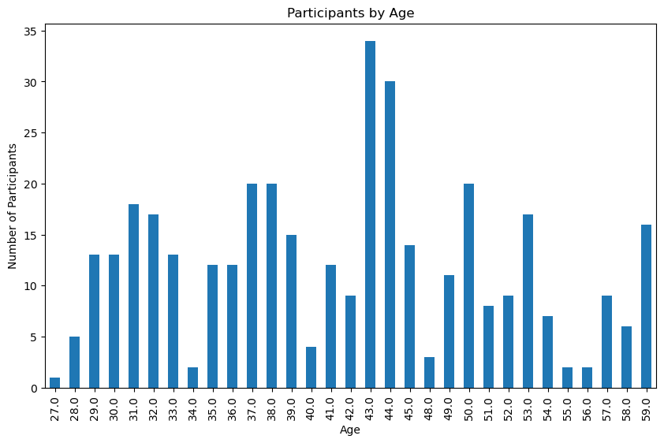

```python
# Plot the participants based on age
age_counts = sleep_health_and_lifestyle_df_tidy['Age'].value_counts()
age_counts.sort_index(inplace=True)

plt.figure(figsize=(10, 6))
age_counts.plot(kind='bar')
plt.title('Participants by Age')
plt.xlabel('Age')
plt.ylabel('Number of Participants')
plt.show()
```

From the age distribution, we see a good spread of participants with a high number in the 43-44 range. There is an interesting correlation between age and number of participants though in almost wave like pattern. These waves go through a 7-8 year cycle. However, we do not see any participants in their early life or older life.

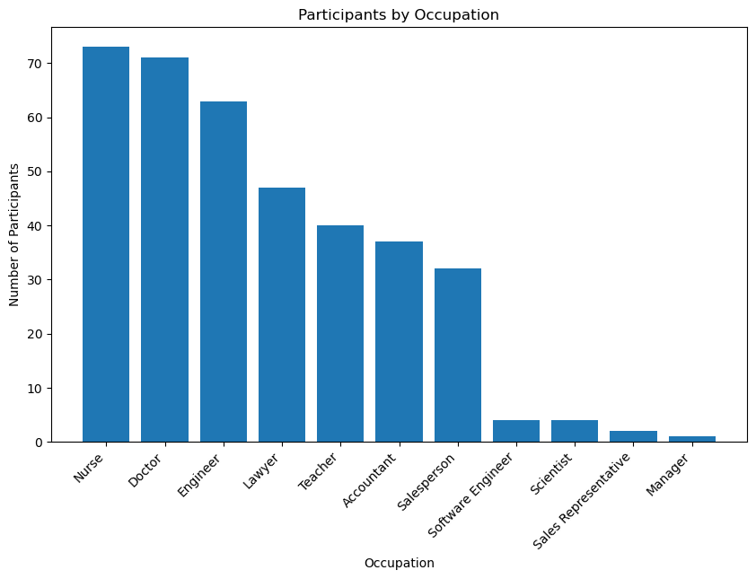

```python
# Plot the participants based on occupation
occupation_counts = sleep_health_and_lifestyle_df_tidy['Occupation'].value_counts()

plt.figure(figsize=(10, 6))
plt.bar(occupation_counts.index, occupation_counts.values)
plt.title('Participants by Occupation')
plt.xlabel('Occupation')
plt.ylabel('Number of Participants')
plt.xticks(rotation=45, ha='right')
plt.show()
```

In the occupation distribution, we see a low variation in the occupations. The majority of participants are nurses, doctors, and engineers. Then we see a good chunk represent lawyers, teachers, accountants, and salespeople. Finally, we see a very small number of software engineers, scientists, sales representatives, and managers.

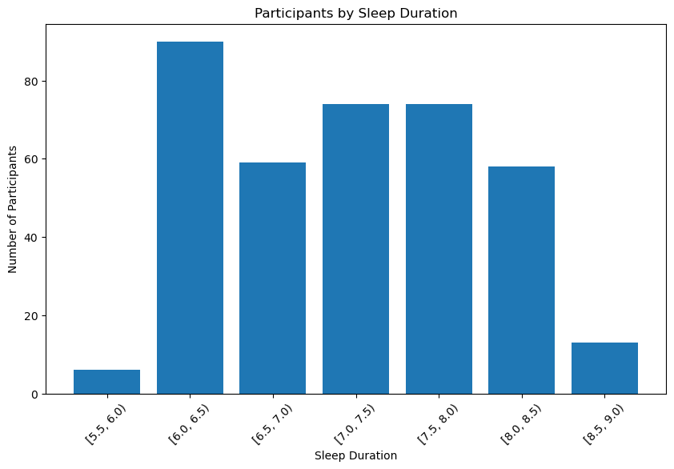

```python
# Plot the participants based on sleep duration
sleep_duration_bins = [5.5, 6, 6.5, 7, 7.5, 8, 8.5, 9]

sleep_duration_counts = pd.cut(sleep_health_and_lifestyle_df['Sleep Duration'], bins=sleep_duration_bins, right=False).value_counts().sort_index()

plt.figure(figsize=(10, 6))
plt.bar(sleep_duration_counts.index.astype(str), sleep_duration_counts.values)
plt.xlabel('Sleep Duration')
plt.ylabel('Number of Participants')
plt.title('Participants by Sleep Duration')
plt.xticks(rotation=45)
plt.show()
```

We will plot different features against stress levels to get a visual idea of what relationships might exist. In this, we are connecting a participants physical and mental factors regarding health, ignoring occupations temporarily.

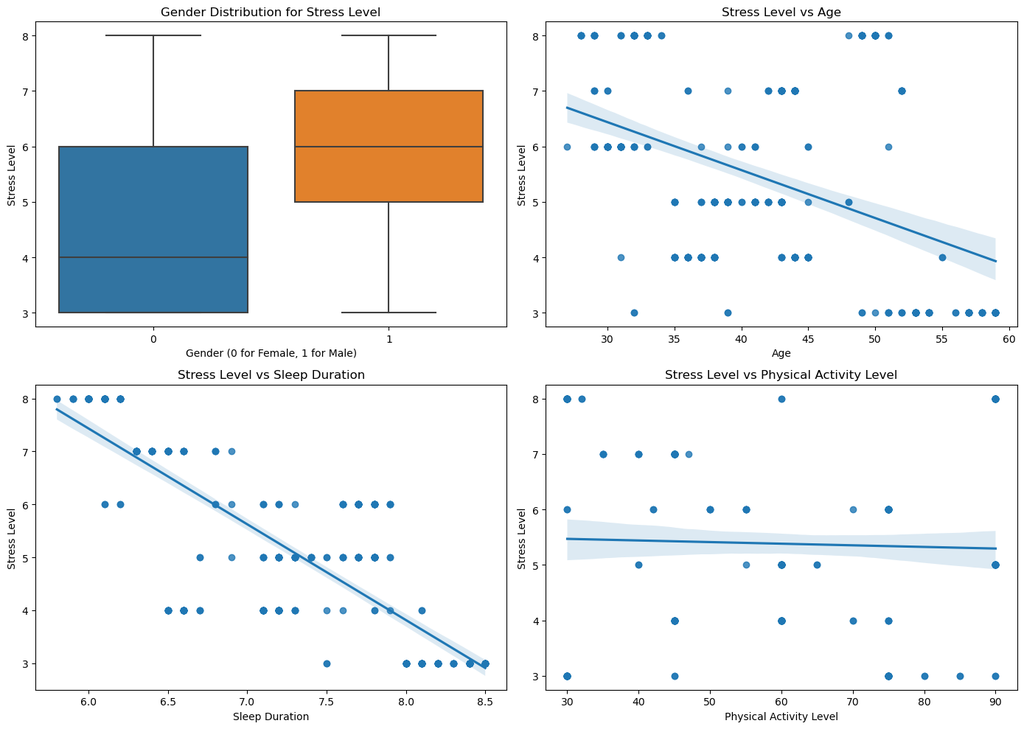

```python
fig, axes = plt.subplots(2, 2, figsize=(14, 10))

# Boxplot Gender Distribution for stress levels
sns.boxplot(x='Gender', y='Stress_Level', data=sleep_health_and_lifestyle_df_tidy,  ax=axes[0, 0])
axes[0, 0].set_title('Gender Distribution for Stress Level')
axes[0, 0].set_xlabel('Gender (0 for Female, 1 for Male)')
axes[0, 0].set_ylabel('Stress Level')

# Plot Relationship between Stress Level and Age
sns.regplot(x='Age', y='Stress_Level', data=sleep_health_and_lifestyle_df_tidy, ax=axes[0, 1])
axes[0, 1].set_title('Stress Level vs Age')
axes[0, 1].set_xlabel('Age')
axes[0, 1].set_ylabel('Stress Level')

# Plot Relationship between Stress Level and Sleep Duration
sns.regplot(x='Sleep_Duration', y='Stress_Level', data=sleep_health_and_lifestyle_df_tidy, ax=axes[1, 0])
axes[1, 0].set_title('Stress Level vs Sleep Duration')
axes[1, 0].set_xlabel('Sleep Duration')
axes[1, 0].set_ylabel('Stress Level')

# Plot Relationship between Stress Level and Physical Activity Level
sns.regplot(x='Physical_Activity_Level', y='Stress_Level', data=sleep_health_and_lifestyle_df_tidy, ax=axes[1, 1])
axes[1, 1].set_title('Stress Level vs Physical Activity Level')
axes[1, 1].set_xlabel('Physical Activity Level')
axes[1, 1].set_ylabel('Stress Level')

plt.tight_layout()
plt.show()
```

These plots give a very general overview of some underlying factors that may impact stress. Thus we must thoroughly compare which of these factors appear to have the strongest impact on stress. Just from observation, we can see that age, physical activity level, and sleep duration all appear to have a relationship with stress levels. The slopes between stress levels vs age and stress levels vs sleep duration is going down much more steeply than the one for stress levels vs physical activity levels.

Now, in the box plot, we can observe the gender distribution for stress and examine its levels based on the inter-quartiles and median. For females, the median stress level is much lower than males and 50% of the data for females falls between stress levels 3 and 6. For males, this range is higher as 50% of the data falls between stress levels 5 and 7. From this we can observe that males within the dataset have a much higher affinity for stress than females.

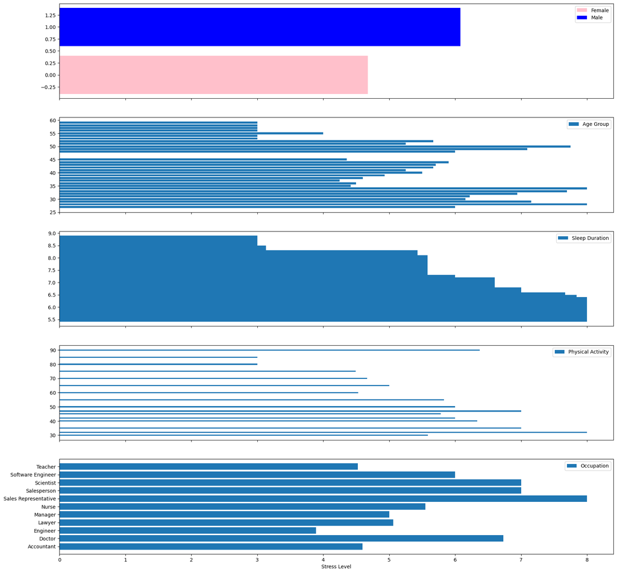

```python
#Mean stress level vs. factors (occupation, age, gender, sleep duration, physicl activity).

# Grouping using different factors such as occupation, gender, age, physical activity, sleep duration
group_gender = sleep_health_and_lifestyle_df_tidy.groupby('Gender')
group_age = sleep_health_and_lifestyle_df_tidy.groupby('Age')
group_sleep_dur = sleep_health_and_lifestyle_df_tidy.groupby('Sleep_Duration')
group_phy_act = sleep_health_and_lifestyle_df_tidy.groupby('Physical_Activity_Level')
group_occupation = sleep_health_and_lifestyle_df_tidy.groupby('Occupation')
graph, plots = plt.subplots(5, figsize=(20,20), sharex=True)

#Plotting mean stress levels for each factor
plots[0]. barh(list(group_gender.groups.keys()), group_gender['Stress_Level'].mean(), color=['pink', 'blue'], label= ['Female', 'Male'])
plots[0].set_label('')
plots[1]. barh(list(group_age.groups.keys()), group_age['Stress_Level'].mean(), label='Age Group')
plots[2]. barh(list(group_sleep_dur.groups.keys()), group_sleep_dur['Stress_Level'].mean(), label = 'Sleep Duration')
plots[3]. barh(list(group_phy_act.groups.keys()), group_phy_act['Stress_Level'].mean(), label = 'Physical Activity')
plots[4]. barh(list(group_occupation.groups.keys()), group_occupation['Stress_Level'].mean(), label='Occupation')
plt.xlabel('Stress Level')

for i in range(5):
    plots[i].legend()
```

Therefore, it is important to understand where the stress in a person's life comes from. Understanding which component contributes to most amount of stress can help us further understand relationship between sleep patterns and factors such as age, gender, occupation, etc.

On this note, it is also important to note that we should consider a correlation matrix to see whether or not certain features within the dataset as a whole have any relationship with each other. Thus, we will create a correlation heatmap to observe the relationships of each feature to the other.

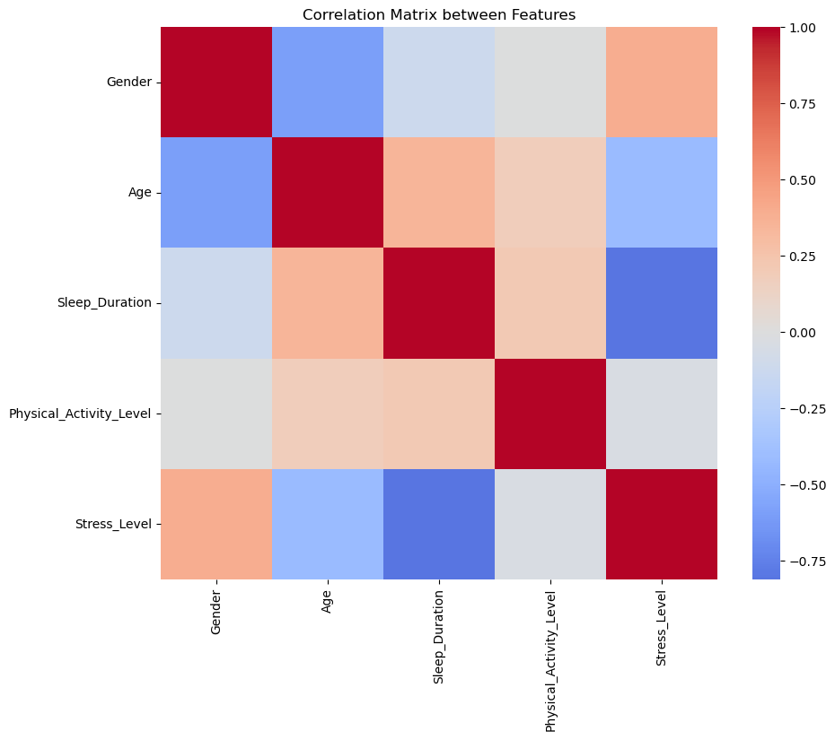

```python
# Select categories with numerical values as we are attempting to work with quantifiable data
numeric_df = sleep_health_and_lifestyle_df_tidy[['Gender', 'Age', 'Sleep_Duration', 'Physical_Activity_Level', 'Stress_Level']]

# Calculate the correlation matrix
correlation_matrix = numeric_df.corr()

# Create a heatmap of the correlation matrix
plt.figure(figsize=(10, 8))
sns.heatmap(correlation_matrix, cmap='coolwarm', center=0)
plt.title('Correlation Matrix between Features')
plt.show()
```

Examining this heat map, we can see that much of the features have vague correlation with each other. For example, physical activity has positively correlated relationships with a few other features, such as age and sleep duration, less intensely than how age has a relationship to sleep duration.

According to a recent 2020 research case-study "Independent and combined associations of sleep duration and sleep quality with common physical and mental disorders: Results from a multi-ethnic population-based study," published by *PLOS ONE*, "'Sleep duration' refers to the total amount of sleep obtained, either during the nocturnal sleep episode or across the 24-h period while 'sleep quality' includes the quantitative aspects of sleep..." (Seow et. al).

As previously stated, for this project, we are solely focusing on sleep duration and not the quality of sleep. We are determining to predict and analyze sleep duration on the basis of various features presented in the data.

## Hypothesis Testing and Data Modeling for "Sleep Health and Lifestyle Dataset" Dataset

We will proceed to make a regression models that forecast stress levels based on our extensive dataset. But before we put it to use, it's a good idea to examine the accuracy of the data using a Z-test. This kind of examination is known as hypothesis testing.

**Null Hypothesis**

The null hypothesis in this case claims that factors like gender, age, the level of physical activity, and sleep duration don't actually impact stress levels.

```python
# Statsmodels ols to get statistic regarding different factors and stress level.
formula = "Stress_Level ~ Gender + Age + Sleep_Duration + Physical_Activity_Level"
sleep_health_lifestyle_stats = stm.ols(formula=formula, data=sleep_health_and_lifestyle_df_tidy).fit()
sleep_health_lifestyle_stats.summary()
```

OLS Regression Results

| Dep. Variable: | Stress_Level | R-squared: | 0.765 |
| --- | --- | --- | --- |
| Model: | OLS | Adj. R-squared: | 0.763 |
| Method: | Least Squares | F-statistic: | 300.9 |
| Date: | Sat, 19 Aug 2023 | Prob (F-statistic): | 1.00e-114 |
| Time: | 14:55:11 | Log-Likelihood: | -473.61 |
| No. Observations: | 374 | AIC: | 957.2 |
| Df Residuals: | 369 | BIC: | 976.8 |
| Df Model: | 4 |  |  |
| Covariance Type: | nonrobust |  |  |

|  | coef | std err | t | P>\|t\| | [0.025 | 0.975] |
| --- | --- | --- | --- | --- | --- | --- |
| Intercept | 16.8748 | 0.450 | 37.479 | 0.000 | 15.989 | 17.760 |
| Gender | 1.0861 | 0.113 | 9.621 | 0.000 | 0.864 | 1.308 |
| Age | 0.0030 | 0.007 | 0.432 | 0.666 | -0.011 | 0.017 |
| Sleep_Duration | -1.8006 | 0.061 | -29.526 | 0.000 | -1.920 | -1.681 |
| Physical_Activity_Level | 0.0114 | 0.002 | 5.129 | 0.000 | 0.007 | 0.016 |

| Omnibus: | 24.005 | Durbin-Watson: | 0.641 |
| --- | --- | --- | --- |
| Prob(Omnibus): | 0.000 | Jarque-Bera (JB): | 16.048 |
| Skew: | -0.382 | Prob(JB): | 0.000327 |
| Kurtosis: | 2.332 | Cond. No. | 766. |

Notes:  
[1] Standard Errors assume that the covariance matrix of the errors is correctly specified.

**Rejecting the Null Hypothesis**

```python
# Parameters from the stats model above. This can help us understand which factor contributes most to stress.
sleep_health_lifestyle_stats.params
```

```
Intercept                  16.874824
Gender                      1.086051
Age                         0.002997
Sleep_Duration             -1.800555
Physical_Activity_Level     0.011436
dtype: float64
```

From these coefficients data, however, we can observe the following:

1. Only sleep duration is negatively correlated with stress levels. Decreases in sleep duration will lead to a possible increase in stress levels.
2. Stress level has the strongest correlation with sleep duration, indicating that it truly has more of an impact on it (although negative).
3. Gender has a strong postive correlation with stress levels, however it has a fairly high standard error. This means that there is bound to be inaccuracies in the data.

Thus, we are rejecting the null hypothesis that none of the considerable features have an impact on stress levels.

Therefore, we can construct Machine Learning models for this purpose. Once we've trained the model, we can visualize the coefficients of the four key features to understand their influence on the final prediction.

We will compare the linear and logisitic regression models to receive an accuracy.

**Linear Regression and Logisistic Regression for Stress Level Forecast**

```
Linear Regression MSE: 0.865137560243149
Logistic Regression Accuracy:  0.8584070796460177
```

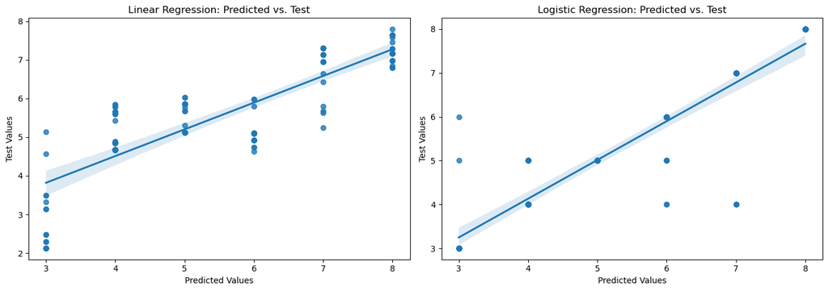

```python
# Select features
selected_features = ["Gender", "Age", "Sleep_Duration", "Physical_Activity_Level"]
feature_indices = [sleep_health_and_lifestyle_df_tidy.columns.get_loc(col) for col in selected_features]

# Split the data into the training and test data
X = sleep_health_and_lifestyle_df_tidy.values[:, feature_indices]
y = sleep_health_and_lifestyle_df_tidy.values[:, -1].astype(float)

# Before fitting the data, we need to implement feature scaling as the four types have different ranges and distributions of data
# Thus, we will standardize the features (mean = 0, std = 1)
scaler = StandardScaler()
scaled_X = scaler.fit_transform(X)

X_train, X_test, y_train, y_test = train_test_split(scaled_X, y, test_size=0.3, random_state=50)

# Compute the Linear Regression Model
linear_regression_model = linear_model.LinearRegression()
linear_regression_model = linear_regression_model.fit(X_train, y_train)

# Calculate MSE
linear_regression_predictions = linear_regression_model.predict(X_test)
linear_regression_mse = mean_squared_error(y_test, linear_regression_predictions)
print("Linear Regression MSE:", linear_regression_mse)

# Compute the Logisitic Regression Model
logistic_regression_model = linear_model.LogisticRegression()
logistic_regression_model.fit(X_train, y_train)

# Calculate the accuracy of the model
logistic_regression_predictions = logistic_regression_model.predict(X_test)
print("Logistic Regression Accuracy: ", logistic_regression_model.score(X_test, y_test))

# Plot predicted vs. actual values from the linear regression
fig, axes = plt.subplots(1, 2, figsize=(14, 5))

sns.regplot(x=y_test, y=linear_regression_predictions, ax=axes[0])
axes[0].set_title('Linear Regression: Predicted vs. Test')
axes[0].set_xlabel('Predicted Values')
axes[0].set_ylabel('Test Values')

sns.regplot(x=y_test, y=logistic_regression_predictions, ax=axes[1])
axes[1].set_title('Logistic Regression: Predicted vs. Test')
axes[1].set_xlabel('Predicted Values')
axes[1].set_ylabel('Test Values')

plt.tight_layout()
plt.show()
```

The Linear Regression MSE value is posed to be 0.86, which indicates that, on average, the squared difference between the predicted stress levels and the actual stress levels is relatively small (compared to the scaling of the data). This suggests that the Linear Regression model is doing a decent job in approximating the stress levels. On the other hand, the accuracy of the logistic regression model is fairly high (.85). This suggests that the Logisitic Regression model is doing well in approximating stress levels. The positive slope in both the scatter plots suggest that the models' predictions increase as the stress level increases.

To better understand the data, we can determine how valuable each feature is. Feature importance indicates the usefulness of each feature in improving the model's accuracy. There are a few ways to indicate feature importance, such as Random Forest Classification. However, Random Forest Classification seems overkill for this fairly simple linear data. Thus, we will stick to the coefficients in the Linear Regression from the predicted data to determine feature importance.

```
Feature Importance:
Sleep_Duration             1.404126
Gender                     0.586580
Physical_Activity_Level    0.217955
Age                        0.031825
dtype: float64
```

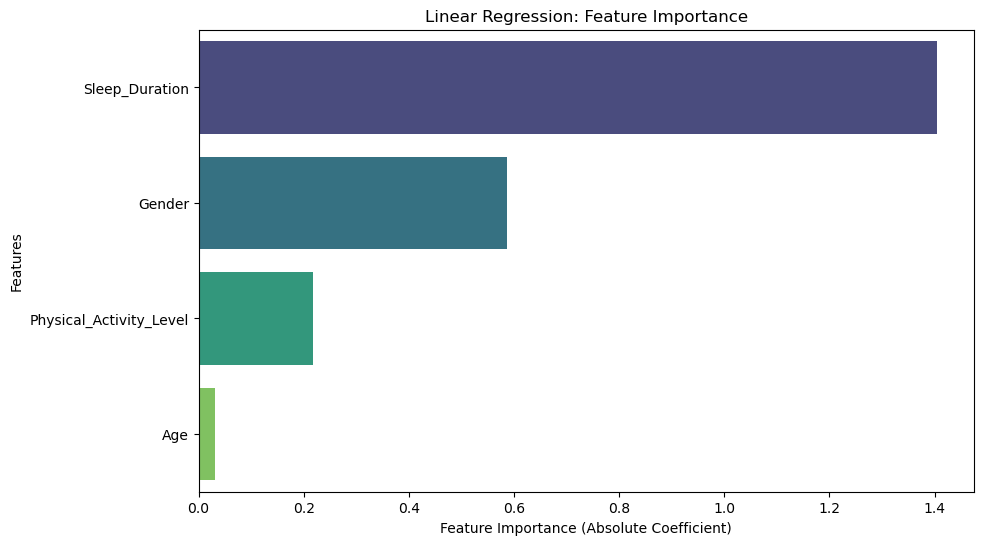

```python
# Find the feature importance vector by taking the coefficients from the Linear Regression
feature_importance = pd.Series(linear_regression_model.coef_, index=selected_features)

# Sort features by importance
sorted_importance = feature_importance.abs().sort_values(ascending=False)

print("Feature Importance:")
print(sorted_importance)

plt.figure(figsize=(10, 6))
sns.barplot(x=sorted_importance.values, y=sorted_importance.index, palette='viridis')
sns.barplot(x=sorted_importance.values, y=sorted_importance.index, palette='viridis')
plt.xlabel('Feature Importance (Absolute Coefficient)')
plt.ylabel('Features')
plt.title('Linear Regression: Feature Importance')
plt.show()
```

We can view that sleep duration is of most importance in accordance to the predicted data. The magnitude of the coefficient (the absolute value) indicates the strength of the relationship. A larger coefficient magnitude implies a stronger impact of the feature on the target variable. In this case, a coefficient value of 1.4041 suggests that sleep duration has a relatively significant influence on predicting stress level among any occupation. It is worth noting that this is based off the whole dataset.

It is more accurate to find the feature importance in regards to each type of occupation.

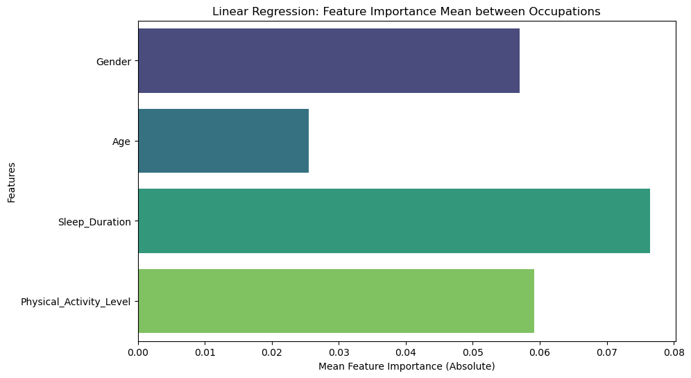

```
[0.0569865104819814,
 0.02548297954316113,
 0.07643300037195416,
 0.05918704312153255]
```

```python
# In accordance to the dataset, there are 11 unqiue occupations
# Create a 2D importance array for the each occupation for every feature
feature_importance_matrix = []

# Iterates through every country once
for job in sleep_health_and_lifestyle_df_tidy['Occupation'].unique():

    # Get the features and the life expectancy data for the country for all 17 years
    X = sleep_health_and_lifestyle_df_tidy[sleep_health_and_lifestyle_df_tidy['Occupation'] == job].values[:, feature_indices]
    y = sleep_health_and_lifestyle_df_tidy[sleep_health_and_lifestyle_df_tidy['Occupation'] == job].values[:, -1].astype(float)

    # Compute the Linear Regression Model.
    linear_regression_model = linear_model.LinearRegression()
    linear_regression_model = linear_regression_model.fit(X, y)

    feature_importance = pd.Series(linear_regression_model.coef_, index=selected_features)
    feature_importance_matrix.append(linear_regression_model.coef_)
feature_importance_matrix = np.array(feature_importance_matrix)

mean_feature_importance = []
mean_feature_importance.append(abs(feature_importance_matrix[:, 0].mean()))
mean_feature_importance.append(abs(feature_importance_matrix[:, 1].mean()))
mean_feature_importance.append(abs(feature_importance_matrix[:, 2].mean()))
mean_feature_importance.append(abs(feature_importance_matrix[:, 3].mean()))

plt.figure(figsize=(10, 6))
sns.barplot(x=mean_feature_importance, y=[col for col in sleep_health_and_lifestyle_df_tidy.columns if col in ['Gender', 'Age', 'Sleep_Duration', 'Physical_Activity_Level']], palette='viridis')
plt.xlabel('Mean Feature Importance (Absolute)')
plt.ylabel('Features')
plt.title('Linear Regression: Feature Importance Mean between Occupations')
plt.show()
mean_feature_importance
```

From the mean feature importance between each occupation, we can still see that sleep duration is of highest importance with a mean feature importance magnitude of .076, for determing stress level.

## Exploratory Analysis and Data Visualization for "Human Stress Detection in and through Sleep" Dataset

**Null Hypothesis:** While certain lifestyle may be more stressful and can have extreme affects on a person's mental health, is there a relationship between stress and hours of sleep? Our null hypothesis as of now is that there is no relationship between sleep and stress.

**Patterns in data**

The charts below help see how sleep is affected by stress level

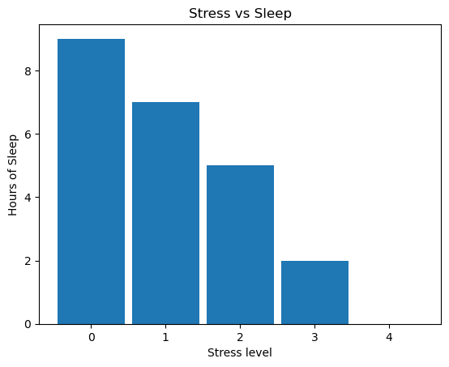

```python
#Data Exploration and Visualization.
#Created bar chart for stress level vs sleep.
plt.bar(stress_detection_and_sleep_df_tidy['stress_level'], stress_detection_and_sleep_df_tidy['sleep_duration'], width=0.90)
plt.xlabel('Stress level')
plt.ylabel('Hours of Sleep')
plt.title('Stress vs Sleep')
```

Human Stress Detection in and through sleep provides us with data that helps track sleep patterns and responses to stress. For example, the above bar chart shows that as stress level goes up, sleep duration goes down. It is important to see the patterns present in the dataset which can aid us in further supporting our hypothesis.

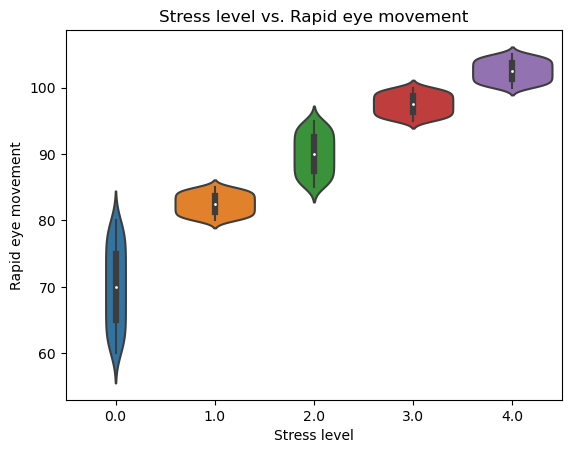

```python
# Violin plot to show concentration of rapid eye movement sleep during different stress levels.
sns.violinplot(data = stress_detection_and_sleep_df_tidy, x='stress_level',y='rem_sleep')
plt.xlabel('Stress level')
plt.ylabel('Rapid eye movement')
plt.title('Stress level vs. Rapid eye movement')
```

The following is another visualization about sleep pattern present in the data. REM sleep also known as rapid eye movement is one of the stages of sleep. The violion plot gives us glimpse into how rem sleep is affected by increased stress.

```python
# Stats model for statistical exploration for stress vs sleep
stress_detection_and_sleep_stats = stm.ols(formula="sleep_duration ~ stress_level", data=stress_detection_and_sleep_df_tidy).fit()
stress_detection_and_sleep_stats.summary()
```

OLS Regression Results

| Dep. Variable: | sleep_duration | R-squared: | 0.947 |
| --- | --- | --- | --- |
| Model: | OLS | Adj. R-squared: | 0.947 |
| Method: | Least Squares | F-statistic: | 1.118e+04 |
| Date: | Sat, 19 Aug 2023 | Prob (F-statistic): | 0.00 |
| Time: | 14:55:14 | Log-Likelihood: | -672.81 |
| No. Observations: | 630 | AIC: | 1350. |
| Df Residuals: | 628 | BIC: | 1359. |
| Df Model: | 1 |  |  |
| Covariance Type: | nonrobust |  |  |

|  | coef | std err | t | P>\|t\| | [0.025 | 0.975] |
| --- | --- | --- | --- | --- | --- | --- |
| Intercept | 7.9000 | 0.049 | 162.361 | 0.000 | 7.804 | 7.996 |
| stress_level | -2.1000 | 0.020 | -105.718 | 0.000 | -2.139 | -2.061 |

| Omnibus: | 48.578 | Durbin-Watson: | 2.170 |
| --- | --- | --- | --- |
| Prob(Omnibus): | 0.000 | Jarque-Bera (JB): | 36.423 |
| Skew: | -0.488 | Prob(JB): | 1.23e-08 |
| Kurtosis: | 2.342 | Cond. No. | 4.74 |

Notes:  
[1] Standard Errors assume that the covariance matrix of the errors is correctly specified.

**Null Hypothesis Rejected**

## Hypothesis Testing and Data Modeling for "Human Stress Detection in and through Sleep" Dataset

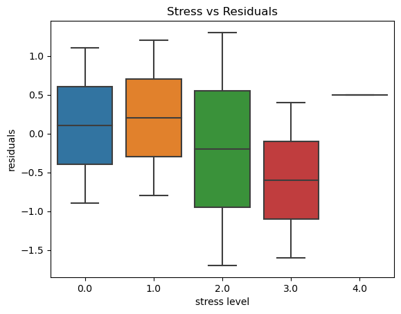

```python
# Stress vs Residual model to see where residuals lie across each stress level using boxplot.

#Values from the table
X = stress_detection_and_sleep_df_tidy['stress_level'].values
y = stress_detection_and_sleep_df_tidy['sleep_duration'].values
reg = linear_model.LinearRegression().fit(X.reshape(-1,1), y)

#Getting the residuals
residuals = y - reg.predict(X.reshape(-1,1))

#Plot using seaborn library
sns.boxplot(x = X, y = residuals )
plt.xlabel('stress level')
plt.ylabel('residuals')
plt.title('Stress vs Residuals')
```

**Stress vs Residual**

Most residual points are centered around cero meaning there is little error between predicted and actual values. Stress level 2 and 3 do have little disparity present meaning that the predicted sleep duration is higher than normal. However, the residual's are still small meaning that the predicted values are close to actual.

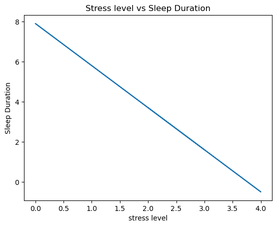

```python
# Linear regression line using predicted values to show the relationship between stress and sleep.
plt.plot(X,reg.predict(X.reshape(-1,1)))
plt.xlabel('stress level')
plt.ylabel('Sleep Duration')
plt.title('Stress level vs Sleep Duration')
```

Regression Line shows a strong negative relationship between stress and sleep. As stress increases, the sleep duration decreases. The predicted values are close to the actual values meaning we can use the regression line to show the relationship between stress and sleep. Prior to this, we saw that the most important feature contributing to stress was lack of sleep.

Considering the relationship above, we can also conlcude that stress does contribute to lack of sleep. We can say that stress is an important feature in determining the quality of sleep a person gets. Considering that certain lifestyles and factors such as age, gender can cause increase in stress which simultaneously also ends up affecting sleep.

## Insight and Potential Policies

- Create a Relaxing Bedtime Ritual: Engage in calming activities like reading, meditating, or gentle stretching.
- Mindfulness and Meditation: Practices like mindfulness meditation can reduce stress and improve sleep quality.
- Work-Life Balance: Set boundaries between work and personal life.
- Seek Support: If occupational stress is significant, consider discussing it with your supervisor or a mental health professional.

Stress management and sleep improvement are ongoing processes that require attention to various aspects of daily life. By implementing these strategies and adjusting them as needed, individuals can create a more balanced lifestyle that supports both mental well-being and healthy sleep patterns.

# References (APA)

Rachakonda, L., Bapatla, A. K., Mohanty, S. P., & Kougianos, E. (2022, February 15). Human Stress Detection in and through Sleep. *Kaggle*. https://www.kaggle.com/datasets/laavanya/human-stress-detection-in-and-through-sleep

Seow, L. S. E., Tan, X., Chong, S. A., Vaingankar, J. A., Abdin, E., Shafie, S., Chua, B. Y., Heng, D., & Subramaniam, M. (2020). Independent and combined associations of sleep duration and sleep quality with common physical and mental disorders: Results from a multi-ethnic population-based study. *PLOS ONE, 15*(7), e0235816. https://doi.org/10.1371/journal.pone.0235816

Tharmalingam, L., et. al. (2023, May 26). Sleep Health and Lifestyle Dataset. *Kaggle*. https://www.kaggle.com/datasets/uom190346a/sleep-health-and-lifestyle-dataset

WebMD. (n.d.). Sleep deprivation and stress: How stress affects sleep. WebMD. https://www.webmd.com/sleep-disorders/tips-reduce-stress

Worley, S. L. (2018). The Extraordinary Importance of Sleep: The Detrimental Effects of Inadequate Sleep on Health and Public Safety Drive an Explosion of Sleep Research. *P & T : A Peer-Reviewed Journal for Formulary Management*, 43(12), 758–763.